# COFFEE

The Artometrics of Java

Coffee is the world’s second-largest traded commodity by value, behind only crude oil. More than 125 million people depend on it for their livelihoods. Around 2.25 billion cups are consumed every day. And yet the country that produces the highest-quality coffee on earth — by a significant margin, according to the Coffee Quality Institute’s own grading data — has exactly zero Starbucks locations. That country is Ethiopia.

This report analyzes 1,339 coffee samples rated by the Coffee Quality Institute (CQI) using the Q Grader scoring methodology, alongside Starbucks’ global store footprint across 73 countries. The CQI dataset covers 10 sensory sub-metrics — aroma, flavor, aftertaste, acidity, body, balance, uniformity, clean cup, sweetness, and cupper points — aggregated into a 100-point total cup score. Together, these two datasets tell a story about quality, market power, and the gap between where the best coffee grows and where the money flows.

## FAST FACTS

1,339 Coffee samples rated by CQI Q Graders across Arabica and Robusta species

85.3 Ethiopia's median CQI cup score — highest of any country with 20+ samples

0 Starbucks locations in Ethiopia, Kenya, and Uganda — the top three scoring nations

16 Countries with 20+ CQI-rated Arabica samples, spanning four continents

25,600 Starbucks locations worldwide across 73 countries, as of the 2018 dataset

## DATASET CONTEXT

The Coffee Quality Institute is a nonprofit that trains and certifies Q Graders — licensed sensory evaluators who score coffee using a standardized 100-point protocol. A sample must score 80 or above to qualify as “specialty coffee.” The CQI dataset made available through TidyTuesday (2020-07-07) contains 1,339 samples spanning Arabica and Robusta species, with individual scores across ten sub-metrics plus a total cup points aggregate. This analysis focuses exclusively on Arabica, which accounts for roughly 60% of global production and uses a different quality rubric than Robusta. After removing one data entry error (a near-zero-score row), the working Arabica dataset contains 1,312 samples from 36 countries.

The Starbucks locations dataset (TidyTuesday 2018-05-07) documents 25,600 individual store locations across 73 countries, with brand, ownership type (company-owned vs. licensed), city, and geographic coordinates. For Chart 2, Starbucks counts were aggregated at the country level and joined to CQI quality scores using ISO-2 country codes. Hawaii is treated as its own origin in the CQI data and is mapped to the US country code for the Starbucks join — the retail overlap is real even if imprecise, since Kona coffee commands premium shelf space in U.S. locations.

The sub-metric fingerprint analysis in Chart 3 covers seven of the ten CQI sub-metrics: aroma, flavor, aftertaste, acidity, body, balance, and cupper points. Uniformity, clean cup, and sweetness were excluded because they function more as defect-penalty fields than sensory attributes — nearly every Arabica sample in the dataset scores at or near the maximum on all three, leaving no meaningful variation to visualize. The top eight countries by sample volume were selected for the heatmap to ensure statistically stable medians.

Country-level analyses were filtered to origins with 20 or more CQI samples to avoid medians driven by one or two unrepresentative submissions. This threshold reduces the country pool from 36 to 16 but substantially improves the reliability of distributional comparisons. All wrangling was performed in R using tidyverse; no imputation was applied to missing values — records with null entries in relevant fields were dropped from the specific chart requiring that field.

**SQL View dataset queries**

```
-- CQI Arabica samples by country (20+ samples, ranked by median score)
SELECT
  country_of_origin,
  COUNT(*)                                          AS n_samples,
  ROUND(MEDIAN(total_cup_points), 2)                AS median_score,
  ROUND(AVG(total_cup_points), 2)                   AS mean_score,
  ROUND(MIN(total_cup_points), 2)                   AS min_score,
  ROUND(MAX(total_cup_points), 2)                   AS max_score
FROM coffee_ratings
WHERE species = 'Arabica'
  AND total_cup_points > 10
  AND country_of_origin IS NOT NULL
GROUP BY country_of_origin
HAVING COUNT(*) >= 20
ORDER BY median_score DESC;

-- Sub-metric fingerprint: median scores per country and attribute
SELECT
  country_of_origin,
  ROUND(MEDIAN(aroma), 2)         AS med_aroma,
  ROUND(MEDIAN(flavor), 2)        AS med_flavor,
  ROUND(MEDIAN(aftertaste), 2)    AS med_aftertaste,
  ROUND(MEDIAN(acidity), 2)       AS med_acidity,
  ROUND(MEDIAN(body), 2)          AS med_body,
  ROUND(MEDIAN(balance), 2)       AS med_balance,
  ROUND(MEDIAN(cupper_points), 2) AS med_cupper_points
FROM coffee_ratings
WHERE species = 'Arabica'
  AND total_cup_points > 10
  AND country_of_origin IN (
    'Ethiopia','Kenya','Costa Rica','Colombia',
    'Guatemala','Honduras','Mexico','Brazil'
  )
GROUP BY country_of_origin
ORDER BY MEDIAN(total_cup_points) DESC;

-- Starbucks store count by country
SELECT
  Country       AS iso2,
  COUNT(*)      AS sbux_stores
FROM starbucks_locations
WHERE Brand = 'Starbucks'
GROUP BY Country
ORDER BY sbux_stores DESC;
```

**Python View dataset queries**

[output not shown]

[output cut: 11 more lines]

```
tmp = tempfile.NamedTemporaryFile(suffix=".xlsx", delete=False)
urllib.request.urlretrieve(
    "https://github.com/rfordatascience/tidytuesday/raw/master/"
    "data/2018/2018-05-07/week6_coffee_chains.xlsx",
    tmp.name
)
sbux = pd.read_excel(tmp.name)
sbux_counts = (
    sbux[sbux["Brand"] == "Starbucks"]
    .groupby("Country")
    .size()
    .reset_index(name="sbux_stores")
    .sort_values("sbux_stores", ascending=False)
)
print(sbux_counts.head(10))
```

## CHART 1 — WHERE GREAT COFFEE COMES FROM

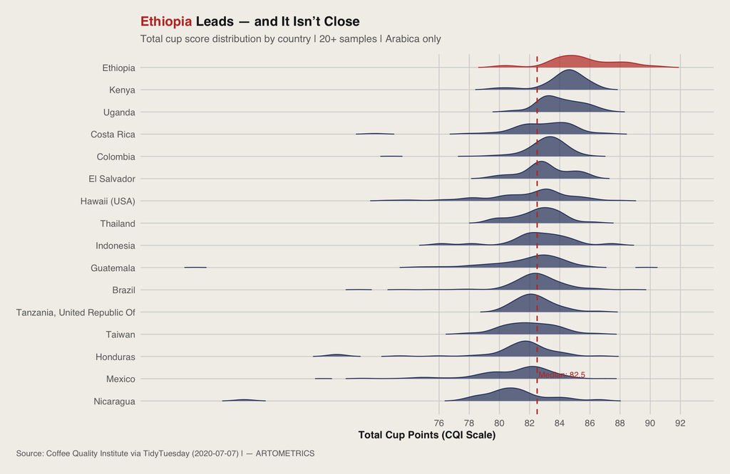

What makes this finding significant is what it implies about terroir and altitude. Ethiopia is the genetic origin of Arabica coffee — the Kaffa region in southwestern Ethiopia is where the species was first documented growing wild. The country’s range of elevation, soil diversity, and processing tradition produces a flavor complexity that Q Graders consistently reward with above-median scores across every sub-metric. This isn’t brand perception. It’s sensory evaluation by licensed professionals using a standardized protocol.

**R View chart code**

```
p1 <- ggplot(
  coffee_countries,
  aes(x     = total_cup_points,
      y     = country_of_origin,
      fill  = is_ethiopia,
      color = is_ethiopia)
) +
  geom_density_ridges(
    alpha          = 0.7,
    scale          = 0.9,
    linewidth      = 0.4,
    rel_min_height = 0.005
  ) +
  geom_vline(
    xintercept = overall_median,
    color      = art_highlight,
    linetype   = "dashed",
    linewidth  = 0.6
  ) +
  annotate(
    "text",
    x     = overall_median + 0.1,
    y     = 2.2,
    label = paste0("Median: ", round(overall_median, 1)),
    color = art_highlight,
    size  = 2.8,
    hjust = 0
  ) +
  scale_fill_manual(values  = c("FALSE" = art_secondary, "TRUE" = art_highlight)) +
  scale_color_manual(values = c("FALSE" = art_secondary, "TRUE" = art_highlight)) +
  scale_x_continuous(breaks = seq(76, 92, 2)) +
  labs(
    title    = "Ethiopia Leads — and It Isn't Close",
    subtitle = "Total cup score distribution by country | 20+ samples | Arabica only",
    x        = "Total Cup Points (CQI Scale)",
    y        = NULL,
    caption  = "Source: Coffee Quality Institute via TidyTuesday (2020-07-07) | — ARTOMETRICS"
  ) +
  theme_artometrics() +
  theme(legend.position = "none")

ggsave("chart1_country_ridgeline.png", p1,
       path = "charts", width = 12, height = 7, dpi = 300, bg = "white")
```

## CHART 2 — THE QUALITY-RETAIL DISCONNECT

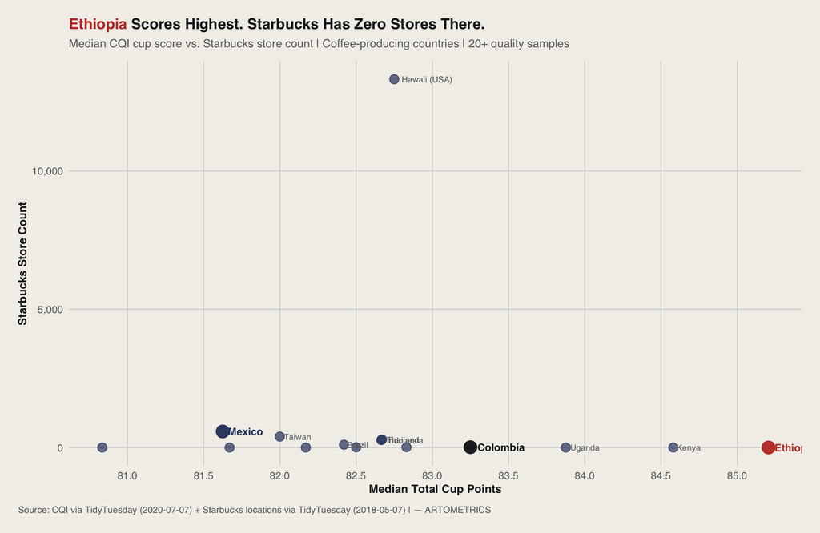

This is not accidental — it is structural. Starbucks builds stores in markets where it can sell coffee, not in markets where it sources coffee. Ethiopia’s retail consumer market is too small and too low-income to support the Starbucks price point. The company sources Ethiopian beans — its Ethiopia single-origin offerings appear in Reserve stores and seasonal rotations — but that sourcing relationship doesn’t translate into a domestic retail presence. The supply chain runs one direction.

**R View chart code**

```
p2 <- ggplot(
  quality_vs_retail,
  aes(x = median_score, y = sbux_stores)
) +
  geom_point(
    data  = filter(quality_vs_retail, highlight == "other"),
    color = art_secondary, size = 3.5, alpha = 0.7
  ) +
  geom_point(
    data = filter(quality_vs_retail, highlight != "other"),
    aes(color = highlight), size = 5, alpha = 0.95
  ) +
  geom_text(
    data = filter(quality_vs_retail, highlight != "other"),
    aes(label = country_of_origin, color = highlight),
    size = 3.2, hjust = -0.15, fontface = "bold"
  ) +
  geom_text(
    data = filter(quality_vs_retail,
                  highlight == "other",
                  sbux_stores > 50 | median_score > 83.5),
    aes(label = country_of_origin),
    color = art_mid, size = 2.6, hjust = -0.15
  ) +
  scale_color_manual(
    values = c(
      "Ethiopia" = art_highlight,
      "Mexico"   = art_secondary,
      "Colombia" = art_dark
    )
  ) +
  scale_y_continuous(labels = comma) +
  scale_x_continuous(breaks = seq(81, 85, 0.5)) +
  labs(
    title    = "Ethiopia Scores Highest. Starbucks Has Zero Stores There.",
    subtitle = "Median CQI cup score vs. Starbucks store count | Coffee-producing countries | 20+ quality samples",
    x        = "Median Total Cup Points",
    y        = "Starbucks Store Count",
    caption  = "Source: CQI via TidyTuesday (2020-07-07) + Starbucks locations via TidyTuesday (2018-05-07) | — ARTOMETRICS"
  ) +
  theme_artometrics() +
  theme(legend.position = "none")

ggsave("chart2_quality_vs_retail.png", p2,
       path = "charts", width = 12, height = 7, dpi = 300, bg = "white")
```

## CHART 3 — THE SUB-METRIC FINGERPRINT

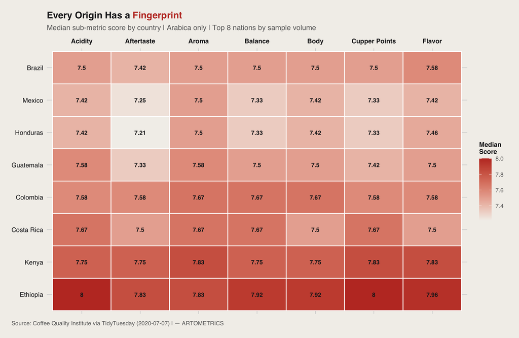

What the heatmap also reveals is how flat the remaining six countries are. Brazil sits at 7.42–7.58 across every dimension — not bad, but undifferentiated. Honduras and Mexico are almost indistinguishable: same Aroma scores (7.5 each), near-identical Acidity and Body. When buyers and roasters talk about commodity coffee, this is the data behind the phrase. Consistent, predictable, no single attribute that dominates or surprises.

**R View chart code**

```
p3 <- ggplot(
  coffee_heatmap,
  aes(x = metric, y = country_of_origin, fill = median_score)
) +
  geom_tile(color = "white", linewidth = 0.5) +
  geom_text(
    aes(label = round(median_score, 2)),
    color = art_dark, size = 2.9, fontface = "bold"
  ) +
  scale_fill_gradient(
    low  = art_cream,
    high = art_highlight,
    name = "Median\nScore"
  ) +
  scale_x_discrete(position = "top") +
  labs(
    title    = "Every Origin Has a Fingerprint",
    subtitle = "Median sub-metric score by country | Arabica only | Top 8 nations by sample volume",
    x        = NULL,
    y        = NULL,
    caption  = "Source: Coffee Quality Institute via TidyTuesday (2020-07-07) | — ARTOMETRICS"
  ) +
  theme_artometrics() +
  theme(
    panel.grid      = element_blank(),
    axis.text.x     = element_text(size = 9, face = "bold", color = art_dark),
    axis.text.y     = element_text(size = 9, color = art_dark),
    legend.position = "right"
  )

ggsave("chart3_submetric_heatmap.png", p3,
       path = "charts", width = 12, height = 7, dpi = 300, bg = "white")
```

## LIMITATIONS

The CQI dataset reflects what Q Graders evaluate — which is not the same as what the global coffee market produces. Samples enter the CQI system because producers, exporters, or buyers choose to submit them. That selection process is not random. Farms that can afford Q Grader evaluations tend to be larger operations or producers already integrated into specialty supply chains. This means lower-quality, subsistence-level production from the same origin countries is systematically underrepresented. Ethiopia’s median score in this dataset may be genuinely high, but it is also the median of the coffees that Ethiopian producers chose to certify.

The Starbucks dataset is from 2018, which limits the currency of the retail analysis. Starbucks has expanded its African presence since then — notably in Morocco and South Africa — though it has not opened locations in Ethiopia, Kenya, or Uganda as of this writing. The directional finding holds, but the store counts should not be treated as current. More importantly, this report uses Starbucks as a proxy for global retail presence because its location data was available as a structured dataset via TidyTuesday. It is not a complete picture of the coffee retail industry — it captures one dominant chain, not the full landscape of cafés, grocery retail, or direct-to-consumer roasting.

Country-level analyses were filtered to origins with 20 or more CQI samples to avoid medians driven by one or two unrepresentative submissions. This threshold reduces the country pool from 36 to 16 but substantially improves the reliability of distributional comparisons. Origins with strong reputations in the specialty trade but fewer CQI submissions — Panama, Yemen, Burundi — are absent from the heatmap entirely, including varieties like Gesha that command the highest auction prices in the market.

## CONCLUSION

The data makes an argument that the coffee industry has spent decades obscuring: quality and market power are not the same thing, and they don’t flow in the same direction. Ethiopia produces the highest-rated coffee in the world by a significant margin. It has no Starbucks locations. Brazil is the world’s largest coffee producer by volume and scores in the bottom half of this quality ranking. The countries that grow the best coffee are not the countries that capture the most economic value from it. That is not a market failure — it is how the market was designed.

What this report can’t capture is what happens between the farm and the cup — the export chain, the roaster markup, the retailer margin. The CQI score is a measure of potential, not of who captures the value that potential creates. Ethiopia’s Q Grader scores are extraordinary. Ethiopian coffee farmers remain among the lowest-paid agricultural workers in the global food system. Both of those things are true at the same time, and neither dataset in this report contradicts the other. The gap between quality and compensation is exactly where the interesting economics live.

## REFERENCES

TidyTuesday (2020-07-07). *Coffee Ratings*. R for Data Science Community. [github.com/rfordatascience/tidytuesday/…/2020-07-07](https://github.com/rfordatascience/tidytuesday/tree/main/data/2020/2020-07-07)

TidyTuesday (2018-05-07). *Coffee Chains*. R for Data Science Community. [github.com/rfordatascience/tidytuesday/…/2018-05-07](https://github.com/rfordatascience/tidytuesday/blob/master/data/2018/2018-05-07)

Coffee Quality Institute. (2020). *Q Grader Program and Cupping Protocols*. Retrieved from coffeeinstitute.org

Samper, L. F., & Quiñones-Ruiz, X. F. (2017). Towards a balanced sustainability vision for the coffee industry. *Resources*, *6*(2), 17. doi.org/10.3390/resources6020017

Daviron, B., & Ponte, S. (2005). *The Coffee Paradox: Global Markets, Commodity Trade and the Elusive Promise of Development*. Zed Books.

Wintgens, J. N. (Ed.). (2009). *Coffee: Growing, Processing, Sustainable Production* (2nd ed.). Wiley-VCH.

## EDITOR’S NOTE

This report was researched, written, designed, and produced in active collaboration with Claude AI (Anthropic). The data pipeline, statistical analysis, chart design, written analysis, narrative structure, and visual styling were all developed through a directed partnership between human editorial judgment and AI execution.

Artometrics was built on the premise that rigorous analysis and honest process are not in conflict. The research questions, editorial instincts, interpretive framing, and brand vision are ours. The execution — every line of R code, every paragraph of analysis, every design decision — was a collaboration. We document this not as a disclaimer but as a description of how we actually work, and as a position: we believe this is what serious data journalism looks like when the tools available are used honestly and at full capacity.

— Artometrics Editorial

[View on GitHub](https://github.com/Artometrics/coffee)